# Презентация лабораторной работы №8

Поиск файлов. Перенаправление ввода-вывода. Просмотр запущенных процессов

Бессонов Андрей Максимович

1032253499@rudn.ru

Российский университет дружбы народов

2026-03-26

# Информация

## Докладчик

- Бессонов Андрей Максимович
- Студент 1-го курса
- Группа НКАбд-01-25
- Российский университет дружбы народов им. П. Лумумбы

# Вводная часть

## Актуальность

- Умение искать файлы в командной строке — ключевой навык для эффективной работы в Linux.
- Перенаправление потоков и конвейеры позволяют гибко обрабатывать данные без создания промежуточных файлов.
- Управление процессами необходимо для контроля выполнения задач, особенно длительных или фоновых.

## Объект и предмет исследования

- **Объект:** Операционная система Linux, её командная оболочка.
- **Предмет:** Инструменты поиска файлов (`find`, `grep`), перенаправление ввода-вывода (`>`, `>>`, `|`), управление процессами (`ps`, `jobs`, `kill`), анализ дискового пространства (`df`, `du`).

## Цели и задачи

- **Цель:** Ознакомление с инструментами поиска файлов и фильтрации текстовых данных. Приобретение практических навыков: по управлению процессами, по проверке использования диска и обслуживанию файловых систем.
- **Задачи:**
  1. Освоить перенаправление стандартных потоков ввода/вывода.
  2. Научиться использовать конвейеры для объединения команд.
  3. Применить команды `find` и `grep` для поиска файлов и фильтрации текста.
  4. Изучить запуск фоновых процессов и управление ими (`jobs`, `ps`, `kill`).
  5. Выполнить анализ дискового пространства с помощью `df` и `du`.

## Материалы и методы

- **Оборудование:** ПК с операционной системой Linux.
- **Программное обеспечение:** Эмулятор терминала, командная оболочка bash.
- **Методы:** Выполнение практических заданий в командной строке, использование встроенной документации (`man`), анализ вывода команд.

# Выполнение работы

## 1–2. Запись списков файлов в `file.txt`

ls /etc > file.txt ls ~ >> file.txt

## 3. Выделение файлов `.conf` в `conf.txt`

grep ‘.conf$’ file.txt > conf.txt cat conf.txt

## 4. Поиск файлов в домашнем каталоге на `c*`

ls ~ | grep ‘^c’

## 5. Постраничный вывод имён файлов из `/etc`, начинающихся с `h`

ls /etc | grep ‘^h’ | less

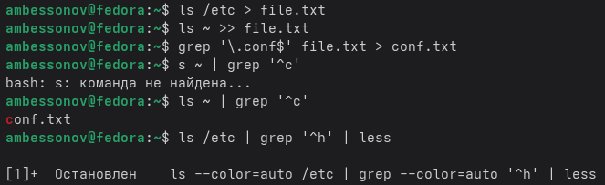

Рис.1

## 6. Запуск фонового процесса для поиска `log*`

find / -name “log*” -print 2>/dev/null > ~/logfile

## 7–8. Удаление `logfile` и запуск `gedit`

rm ~/logfile gedit &

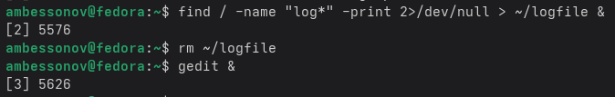

Рис.2

## 9. Определение PID процесса `gedit`

ps aux | grep gedit | grep -v grep

## 10. Изучение `man kill` и завершение процесса

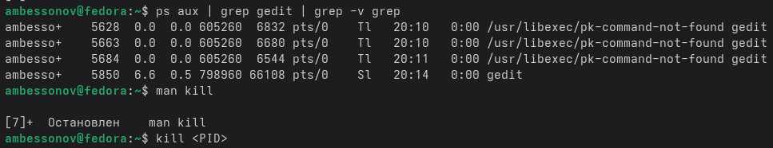

Рис.3

## 11. Анализ дискового пространства (`df`, `du`)

man df man du df -h du -sh ~

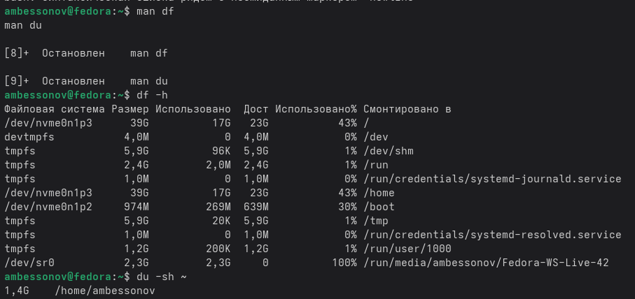

Рис.4

## 12. Вывод всех директорий в домашнем каталоге

find ~ -type d

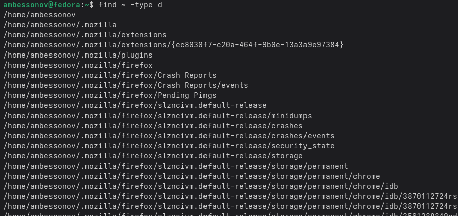

Рис.5

# Заключение

## Вывод

В результате выполнения лабораторной работы были успешно приобретены практические навыки работы с командной строкой Linux в части поиска файлов, фильтрации данных, управления процессами и контроля дискового пространства. Полученные знания являются важной основой для дальнейшего изучения системного администрирования и автоматизации задач в Unix-подобных операционных системах.